# Bayesian Decision Analysis for Integrated Orchard Management

Cory Whitney

2025-09-27

# 1 Bayesian Decision Analysis for Integrated Orchard Management

## 1.1 Background

You are considering introducing sheep into your apple orchard, a practice known as “agroforestry” or “integrated farming.” This approach promises multiple benefits but also carries significant uncertainties. The decision involves complex trade-offs between costs, benefits, and risks that are difficult to quantify with traditional analysis.

## 1.2 The Decision Context

### 1.2.1 Current Situation

- **Apple orchard**: Established operation with known annual revenues
- **Opportunity**: Introduce sheep for wool/meat production while benefiting orchard health
- **Challenge**: Multiple uncertain factors make traditional cost-benefit analysis inadequate

### 1.2.2 Key Uncertain Variables

#### 1.2.2.1 Costs (Annual)

- **Initial investment**: Fencing, watering systems, sheep purchase
- **Operating costs**: Feed supplements, veterinary care, labor
- **Potential losses**: Sheep damage to trees, increased management complexity

#### 1.2.2.2 Benefits

- **Direct revenue**: Wool, meat, lamb sales
- **Orchard benefits**: Natural fertilization, weed control, reduced mowing costs
- **Ecosystem services**: Improved soil health, biodiversity enhancement

#### 1.2.2.3 Risks

- **Animal health risks**: Disease outbreaks, predation losses
- **Market risks**: Fluctuating wool/meat prices
- **Orchard risks**: Tree damage, soil compaction, regulatory changes

## 1.3 The Analytical Challenge

### 1.3.1 Problem 1: Parameter Uncertainty

We have initial estimates with 90% confidence intervals, but these ranges are wide:

- Costs: $5,000 - $15,000 annually
- Benefits: $8,000 - $20,000 annually
- Failure probability: 10% - 30%

### 1.3.2 Problem 2: Incorporating New Information

We’ve gathered observational data from another farm, but:

### 1.3.3 Problem 3: Decision Complexity

The decision requires answering:

1. What is the **expected net benefit**?
2. What is the **probability of positive returns**?
3. What are the **potential downside risks**?
4. How **robust** is the decision to changing assumptions?

## 1.4 Bayesian Monte Carlo Approach

### 1.4.2 Why Monte Carlo Simulation?

- **Propagate uncertainty**: Track how input uncertainties affect output uncertainty
- **Scenario analysis**: Explore thousands of possible futures
- **Risk assessment**: Quantify probabilities of different outcomes

## 1.6 Expected Outcomes

The analysis will provide:

## 1.7 Practical Significance

This approach demonstrates how farmers can make better decisions under uncertainty by:

- Systematically incorporating different types of information
- Quantifying risks rather than ignoring them
- Making transparent, defensible decisions
- Planning for multiple possible futures

The methodology is transferable to other agricultural decisions involving:

- New technology adoption
- Crop diversification
- Sustainable practice implementation
- Climate adaptation strategies

We provide a simple R script that demonstrates how to use Monte Carlo simulation with Bayesian updating for farm decision:

## 1.8 Simple Bayesian Monte Carlo for Farm Decision Analysis

Introducing sheep in apple orchard

```r
set.seed(123) # For reproducible results
```

## 1.9 Define prior distributions (90% confidence intervals)

Using normal distributions for simplicity

```r
# Prior parameters (mean and sd based on 90% CI)
# Assuming 90% CI is mean ± 1.645*sd
calculate_prior <- function(lower, upper) {
  mean_val <- (lower + upper) / 2
  sd_val <- (upper - lower) / (2 * 1.645) # 1.645 for 90% CI
  return(list(mean = mean_val, sd = sd_val))
}
```

## 1.10 Prior distributions for costs, benefits, and risks

```r
cost_prior <- calculate_prior(lower = 5000, upper = 15000)    # Annual costs ($)
benefit_prior <- calculate_prior(lower = 8000, upper = 20000) # Annual benefits ($)
risk_prior <- calculate_prior(lower = 0.1, upper = 0.3)       # Probability of failure
```

## 1.11 New observations from other farm

```r
observations <- list(
  wool_price_obs = 12.5,    # $/kg observed wool price
  fertility_gain_obs = 0.15, # Observed fertility improvement
  risk_obs = 0.18           # Observed failure rate
)
```

## 1.12 Bayesian updating function

```r
bayesian_update <- function(prior_mean, prior_sd, observed_value, obs_sd = 0.1) {
  # Simple conjugate prior update for normal distribution
  prior_precision <- 1 / (prior_sd^2)
  obs_precision <- 1 / (obs_sd^2)

  posterior_mean <- (prior_precision * prior_mean + obs_precision * observed_value) /
                    (prior_precision + obs_precision)
  posterior_sd <- sqrt(1 / (prior_precision + obs_precision))

  return(list(mean = posterior_mean, sd = posterior_sd))
}
```

```r
cost_posterior <- bayesian_update(cost_prior$mean, cost_prior$sd,
                                 observations$wool_price_obs * 400) # Convert to annual cost
benefit_posterior <- bayesian_update(benefit_prior$mean, benefit_prior$sd,
                                    observations$fertility_gain_obs * 100000) # Convert to monetary value
risk_posterior <- bayesian_update(risk_prior$mean, risk_prior$sd,
                                 observations$risk_obs)
```

## 1.14 Monte Carlo simulation

```r
n_simulations <- 10000

# Sample from posterior distributions
costs_sim <- rnorm(n_simulations, cost_posterior$mean, cost_posterior$sd)
benefits_sim <- rnorm(n_simulations, benefit_posterior$mean, benefit_posterior$sd)
risks_sim <- rnorm(n_simulations, risk_posterior$mean, risk_posterior$sd)

# Ensure risks are between 0 and 1
risks_sim <- pmax(0, pmin(1, risks_sim))

# Calculate net benefits (accounting for risk)
net_benefits <- (benefits_sim - costs_sim) * (1 - risks_sim)

# Decision analysis results
results <- list(
  expected_net_benefit = mean(net_benefits),
  probability_positive = mean(net_benefits > 0),
  confidence_interval = quantile(net_benefits, c(0.05, 0.95)),
  risk_exposure = mean(net_benefits < -5000) # Probability of significant loss
)
```

## 1.16 Plot results

```r
# Load required packages
library(ggplot2)
library(dplyr)
library(tidyr)
library(patchwork)  # For combining plots

# Create data frames for plotting
net_benefits_df <- data.frame(net_benefits = net_benefits)
costs_df <- data.frame(
    value = costs_sim,
    type = "Posterior"
)
benefits_df <- data.frame(
    value = benefits_sim,
    type = "Posterior"
)
risks_df <- data.frame(
    value = risks_sim,
    type = "Posterior"
)

# Add prior distributions for comparison
set.seed(123)
n_prior <- 10000
costs_df_prior <- data.frame(
    value = rnorm(n_prior, cost_prior$mean, cost_prior$sd),
    type = "Prior"
)
benefits_df_prior <- data.frame(
    value = rnorm(n_prior, benefit_prior$mean, benefit_prior$sd),
    type = "Prior"
)
risks_df_prior <- data.frame(
    value = pmin(1, pmax(0, rnorm(n_prior, risk_prior$mean, risk_prior$sd))),
    type = "Prior"
)

# Combine prior and posterior
costs_combined <- rbind(costs_df, costs_df_prior)
benefits_combined <- rbind(benefits_df, benefits_df_prior)
risks_combined <- rbind(risks_df, risks_df_prior)
```

### 1.16.1 Plot 1: Net Benefits Distribution

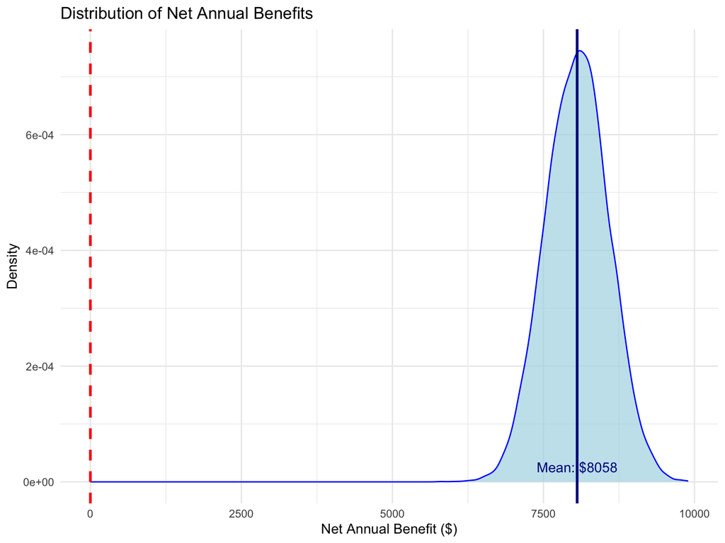

```r
p1_net_benefits <- ggplot(net_benefits_df, aes(x = net_benefits)) +
    geom_density(fill = "lightblue", alpha = 0.7, color = "blue") +
    geom_vline(xintercept = 0, color = "red", linetype = "dashed", size = 1) +
    geom_vline(xintercept = mean(net_benefits), color = "darkblue", size = 1) +
    labs(title = "Distribution of Net Annual Benefits",
         x = "Net Annual Benefit ($)",
         y = "Density") +
    theme_minimal() +
    annotate("text", x = mean(net_benefits), y = 0,
             label = paste("Mean: $", round(mean(net_benefits)), sep = ""),
             vjust = -1, color = "darkblue")
p1_net_benefits
```

### 1.16.2 Plot 2: Costs - Prior vs Posterior

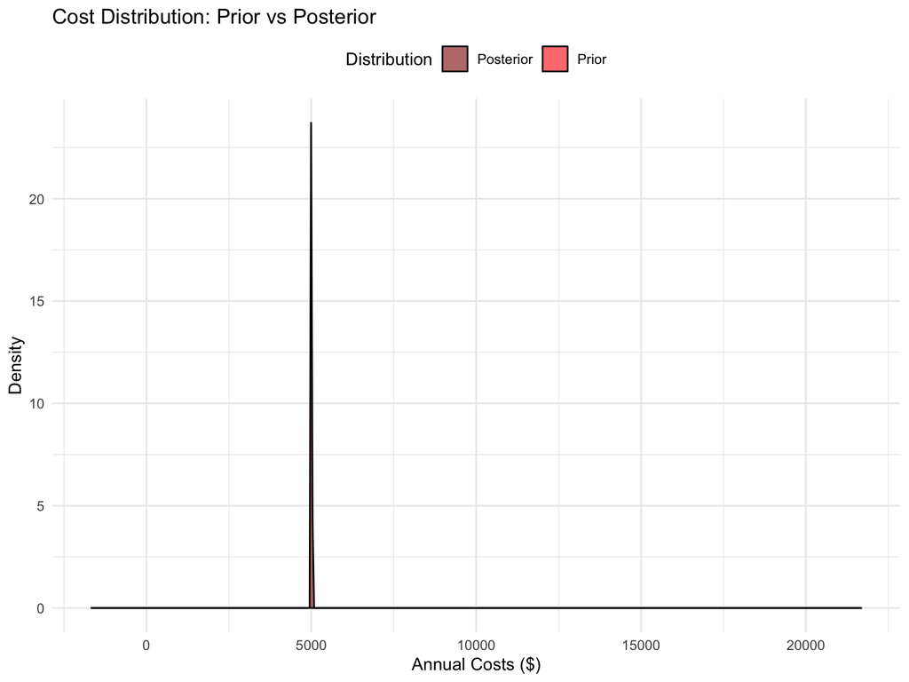

```r
p2_costs_combined <- ggplot(costs_combined, aes(x = value, fill = type)) +
    geom_density(alpha = 0.6) +
    labs(title = "Cost Distribution: Prior vs Posterior",
         x = "Annual Costs ($)",
         y = "Density",
         fill = "Distribution") +
    scale_fill_manual(values = c("Prior" = "red", "Posterior" = "darkred")) +
    theme_minimal() +
    theme(legend.position = "top")

p2_costs_combined
```

### 1.16.3 Plot 3: Benefits - Prior vs Posterior

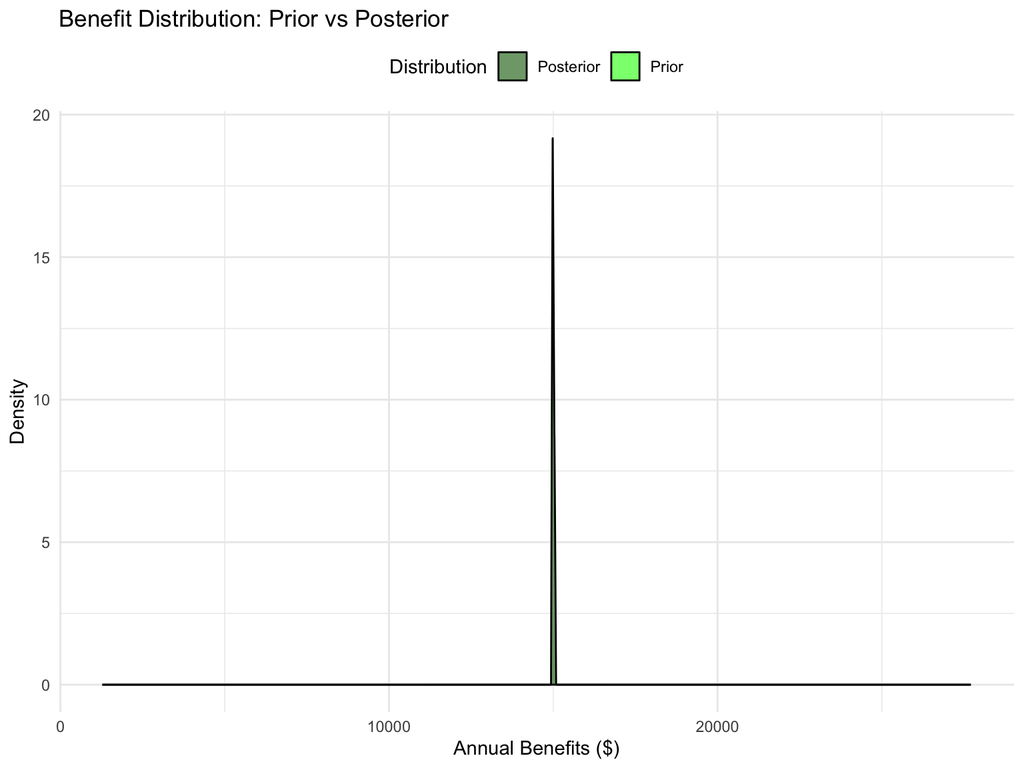

```r
p3_benefits_combined <- ggplot(benefits_combined, aes(x = value, fill = type)) +
    geom_density(alpha = 0.6) +
    labs(title = "Benefit Distribution: Prior vs Posterior",
         x = "Annual Benefits ($)",
         y = "Density",
         fill = "Distribution") +
    scale_fill_manual(values = c("Prior" = "green", "Posterior" = "darkgreen")) +
    theme_minimal() +
    theme(legend.position = "top")
p3_benefits_combined
```

### 1.16.4 Plot 4: Risks - Prior vs Posterior

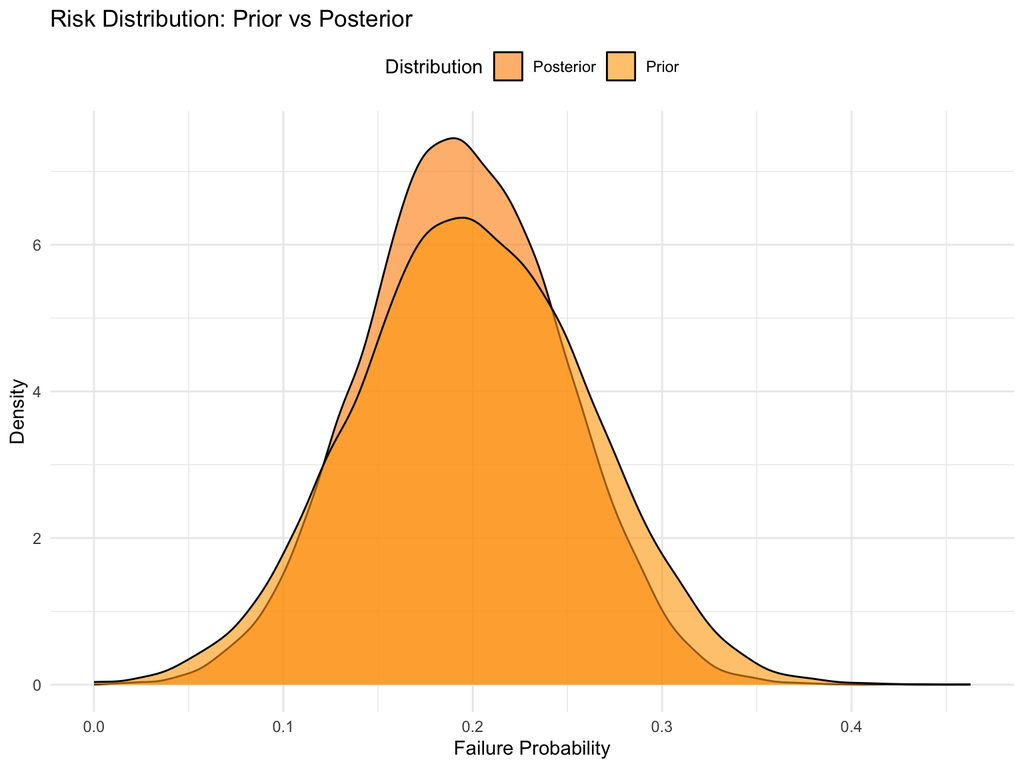

```r
p4_risks_combined <- ggplot(risks_combined, aes(x = value, fill = type)) +
    geom_density(alpha = 0.6) +
    labs(title = "Risk Distribution: Prior vs Posterior",
         x = "Failure Probability",
         y = "Density",
         fill = "Distribution") +
    scale_fill_manual(values = c("Prior" = "orange", "Posterior" = "darkorange")) +
    theme_minimal() +
    theme(legend.position = "top")
p4_risks_combined
```

### 1.16.5 Combined plots

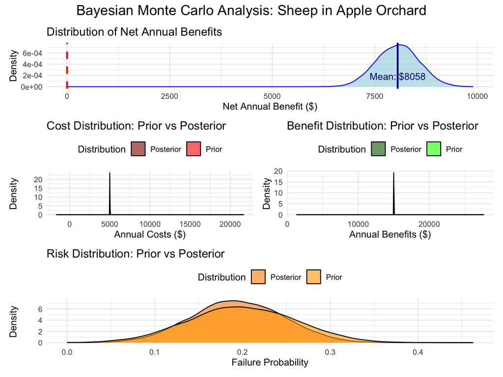

```r
(p1_net_benefits) / (p2_costs_combined + p3_benefits_combined) / (p4_risks_combined) +
    plot_annotation(title = "Bayesian Monte Carlo Analysis: Sheep in Apple Orchard",
                   theme = theme(plot.title = element_text(hjust = 0.5, size = 16)))
```